# index

STATS 220 Semester One 2023

Francesca Domanska

2023-05-09

## Index

I wanted to use certain variables to focus on the use of Te Reo in emails throughout the week and also, look at the tone of emails and if stressor words such as (test, exam, lab) had some sort of relationship with the sentiments of the subject and body of the emails. I’m passionate about the use of Te Reo in our everyday lives and also different factors that affect student mental health. As a student, I find that the usage of Te Reo often is used for emails broad emails when the email tone is already positive, and that more serious emails do not include them. I want to see if there is a certain bias to use of Te Reo and formalities when emails have a negative tone or not. For my first graph I wanted to see how many emails were sent per day of the week and if Te Reo was used more on certain days. This is because I’m curious about whether Te Reo is more commonly used during class announcements and class wide emails compared to personal/direct emails. With further investigation about whether emails were directed to certain people, I could further investigate this.

I created variables using the mutate() function to find emails that included common Maori terms such as “Kia ora” or “Ngā mihi”, and then used this information to create a visualisation. For my first visualisation I chose a bar graph as all of my data was categorical and it really highlighted the different frequencies of emails sent throughout the week. For my second static visualisation, I used a scatter plot. I wanted to see if there were clusters at certain sentiment positive and negative combinations, and if stressor words were more commonly clustered in emails with negative sentiments. For my dynamic visualisation, I chose a box plot as it clearly highlighted the spread and range of frequencies between use of stressor words in emails with and without Te Reo. I applied “grammar of graphics” in some way for all my graphs. Key examples were by the use of the aes() where I used functions such as fill() to make my data multidimensional (i.e. showing frequency of emails during days of the week AND presence of Maori terms). I used labs() to include labels on my visualisations, so that other’s can clearly tell what my graph is saying. I used theme() to manipulat text features part of the graph. I also used facet() on the static version of my dynamic graph to highlight the differences between frequencies of stressor words in emails with and without Te Reo.

I tried multiple variations of visualisations which I did not end up using. For example, I tried creating a bar chart of days of the week comparing if the emails were work emails or student emails. However, I decided to completely scratch the usage of the variable work, as it required me to identify email addresses, which I eventually decided to avoid to consider privacy.I also wanted to try graph sentiment analysees as box plots or bar graphs, but as they were not categorical variables, it looked far too messy to interpret. I also tried to use sentiment data for my dynamic graph but similarly it looked very chaotic. I instead decided to make the variable “stressors_present”, as similarly to how sentiment analyses the tone of the email, the presence of stressor words, could also envoke certain emotions.

## Visualisations

**The first static graph I visualised:**

[figure not shown]

This visualization shows that based on the mode, Monday has the highest amount of emails sent or received. This makes sense with my presumption that there are class wide announcements at the beginning of the week. The usage of Te Reo is used in almost half the emails, suggesting that its usage is less dependent on intentional usage during class wide announcements, and perhaps a personal choice. To back this idea, I’d have to make further visualisations using personal information. Thursdays seem to have the highest usage of Te Reo, which could potentially be related to pre-weekend announcements.

**The second static graph I visualised:**

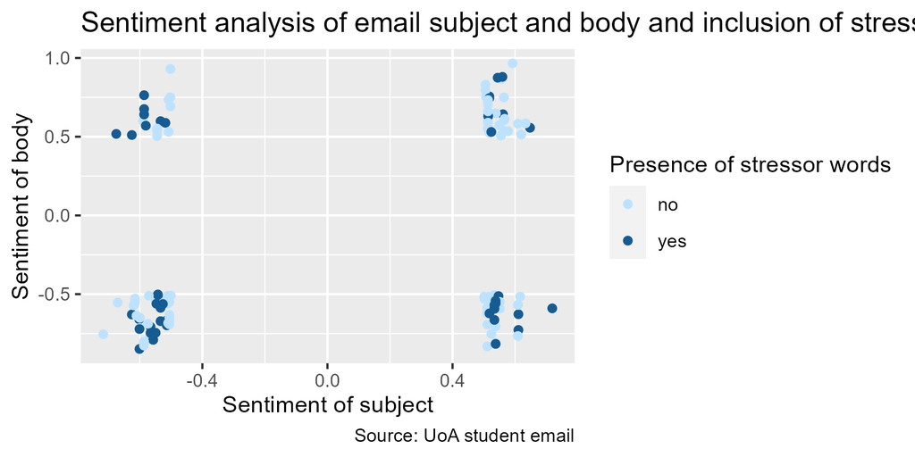

This visualisation shows that there are higher more points of data where both subject and body sentiment are either both positive or both negative. However, it does appear that emails with negative sentiments tend to have a higher frequency of stressor words. I think this could be because emails that talk about class results, or upcoming events, could automatically have a negative or anxious tone.

**The dynamic graph I visualised:**

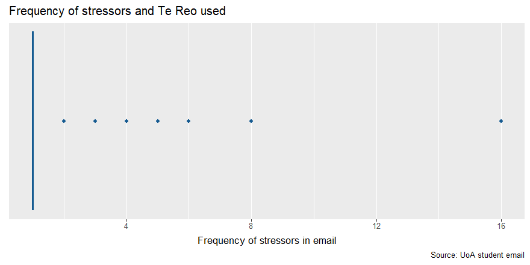

## Learning reflections

An important idea I learnt from Module 4 is about anonymising the data by removing who the email was sent from or received by. This can also be done by removing any names included in the email subject and body. If information from an email database were to be from a company, it would be important to protect the privacy of customers and other businesses, as this could lead to email addresses being leaked which could cause scamming. I did not consider privacy an issue in this particular assessment however, it was useful to learn.I tried my best to protect people’s privacy by removing the variables email_from and email_to, but struggled to remove other identifiers from the body and subject.

I think this assingment shows creativity because of my use of creating new variables. I wanted to create unique variables relating to the usage of Te Reo, because I think it’s important that we use it in everyday life. This allowed for further critical thinking and consider how the use of Te Reo is used in combination with stressor words. I think inclusive language can definitely affect student mental health and therefore it’s important to see how its combined with stressor terms. I also used separate code to enhance my ability to interpret the data by creating the days of the week into a string, which allowed me to graph it. I could have avoided using this variable as it created extra work, however by using the factor() function, I was able to incorporate what I know from this module, with basic string knowledge from previous modules and use a new function to tie it all together.

I am interested in further exploring using facets when making visualizations. With the variables I decided to look at, there wasn’t as much room to create visualizations with as many facets compared to in Lecture 4B1, however I’d like to further explore the use of that grammar tool. I’m a visual learner, so finding new ways to graph things allows me to find ways to read data in a more straightforward way.

## Appendix

```r
library(tidyverse)
library(gganimate)

#Read csv file and use mutate() function to add new variables
email_data <- read.csv("https://docs.google.com/spreadsheets/d/e/2PACX-1vQCgfNt9Xfhy7NGgJJsW7BZtlS7MPl2EO4jnNGgYTKER641XRjYxOkwcIwRHIKj60vIoxG4YiuFjHaB/pub?gid=0&single=true&output=csv") %>%
  rename(day = email_day,
         hour = email_hour,
         sent_sub = sentiment_subject,
         sent_body = sentiment_body) %>%
  select(day, hour, sent_sub, sent_body, email_body) %>%
  mutate(weekend = str_count(day, c("Saturday|Sunday")) + 1)%>%
  mutate(weekend_yes = ifelse(weekend >= 2, "yes", "no")) %>%
  mutate(body_words = str_to_lower(email_body)) %>%
  mutate(stressors_present = str_count(body_words, "lab|test|exam") + 1) %>%
  mutate(stressors = ifelse(stressors_present >= 2, "yes", "no")) %>%
  #filter(work_email == "no") %>%
  mutate(body_greetings = str_count(body_words, "kia ora|ngā mihi") + 1) %>%
  mutate(body_maori = ifelse(body_greetings >= 2, "yes", "no")) %>%
  mutate(body_te_reo = str_count(body_maori, "yes") + 1) %>%
  arrange(day) %>%
view()

#View data in table
view(email_data)

#Grouping by day to find mean hour
email_data %>%
    group_by(day) %>%
    summarise(mean_hour = mean(hour))

#Counting how many emails sent per day
  day_summarise <- email_data %>%
    count(day)

#Using to order days of week for bar graph
days_of_the_week <- email_data %>%
  c("Monday", "Tuesday", "Wednesday", "Thursday", "Friday", "Saturday", "Sunday")


# Not using as there wasn't very much data to fill the graph
#email_data %>%
  #ggplot(aes(x = hour,
  # y = 5)) + # hack to use box plot
  #with one variable
  #geom_boxplot() +
  #scale_y_continuous(NULL, breaks = NULL) + # yaxis labels not needed
  #facet_wrap(vars(weekend))

# Not using as there wasn't very much data to fill the graph
#email_data %>%
  #ggplot(aes(x = body_greetings,y = 5)) +
  #geom_boxplot() +
  #scale_y_continuous(NULL, breaks = NULL) +
  #facet_wrap(vars(work_email))

# STATIC Graph Days of the week
#email_data %>%
  #ggplot() +
  #geom_bar(aes(x = day,
               #fill = work_email)) +
  #scale_fill_manual(values=c("#42a7f5", "#f542e3")) +
  # Changing the captions and axis
  #labs(title = "Emails on days of the week comparing work emails vs university emails",
        #x = "Days of the week",
        #y = "Number of emails",
        #caption = "Source: UoA student email")

# STATIC Graph Days of the week
days_te_reo <- email_data %>%
  ggplot() +
  geom_bar(aes(x = factor(day, days_of_the_week),
              fill = body_maori)) +
  scale_fill_manual(values=c("#bde2ff", "#165b91")) +
    # Changing the captions and axis
  labs(title = "Emails on days of the week comparing work emails vs university emails",
         x = "Days of the week",
         y = "Number of emails",
         fill = "Te Reo present",
         caption = "Source: UoA student email")

days_te_reo
#Saving the graph
ggsave("days_of_the_week.png", width = 7, height= 4, units = "in")


# STATIC Graph Sentiment of subject and body for emails with triggering words
sent <- email_data %>%
  ggplot() +
  geom_point(aes(x = sent_sub,
                 y = sent_body,
                 color = stressors)) +
  scale_color_manual(values=c("#bde2ff", "#165b91")) +
  # Changing the captions and axis
  labs(title = "Sentiment analysis of email subject and body and inclusion of stress trigerring words",
       x = "Sentiment of subject",
       y = "Sentiment of body",
       color = "Presence of stressor words",
       caption = "Source: UoA student email") +
  theme(legend.position = "right")

sent

#Saving the graph
ggsave("sent.png", width = 6, height= 3, units = "in")

#animate_graph <- email_data %>%
#ggplot() +
#geom_line(aes(x = sent_sub,
#y = sent_body)) +
#transition_reveal(sent_sub) +
#labs(title = "Sentiment of subject compared to sentiment of body",
#x = "Sentiment of subject",
#y = "Sentiment of body",
#caption = "Source: UoA student email")


# DYNAMIC Graph Frequency of stressors and Te Reo used
anim <- email_data %>%
  ggplot(aes(x = stressors_present,
             y = 5)) +
  geom_boxplot(color = "#165b91", fill = "#bde2ff") +
  scale_y_continuous(NULL, breaks = NULL) +
  #facet_wrap(vars(body_te_reo))
  transition_reveal(body_te_reo) +
  labs(title = "Frequency of stressors and Te Reo used",
  x = "Frequency of stressors in email",
  caption = "Source: UoA student email") +
  theme(legend.position = "none")


anim

animate(anim, width = 8, height = 4, units ="in", res = 110)

#Saving the animation
anim_save("te_reo_stressors.gif", format = gif)

# STATIC Graph Frequency of stressors and Te Reo used (Same as dynamic)
stat <- email_data %>%
  ggplot(aes(x = stressors_present,
             y = 5,
             color = "#CF53f5")) +
  geom_boxplot() +
  scale_y_continuous(NULL, breaks = NULL) +
  facet_wrap(vars(body_te_reo))
#transition_reveal(body_te_reo) +
labs(title = "Frequency of stressors and Te Reo used",
     x = "Frequency of stressors in email",
     caption = "Source: UoA student email") +
  theme(legend.position = "none")


stat
```